# CHarris_HW3

CarterH

2/25/2020

```r
Insurance_Data.df <- read.csv("C:/Users/Carter Harris/OneDrive/Soph year, Spring/BIA 3200/HW3/Insurance_DS.csv", header=TRUE)
```

Start by swapping NA values for the average in each column.

```r
Insurance_Data.df[9, 1] <- 39

Insurance_Data.df[1338, 1] <- 39

Insurance_Data.df[2, 7] <- 13272

Insurance_Data.df[99, 7] <- 13272
```

Check to make sure there aren’t any NAs left.

```r
summary(Insurance_Data.df$age)
```

```
##    Min. 1st Qu.  Median    Mean 3rd Qu.    Max.
##   18.00   27.00   39.00   39.19   51.00   64.00
```

```r
summary(Insurance_Data.df$sex)
```

```
## female   male
##    662    676
```

```r
summary(Insurance_Data.df$bmi)
```

```
##    Min. 1st Qu.  Median    Mean 3rd Qu.    Max.
##   15.96   26.30   30.40   30.66   34.69   53.13
```

```r
summary(Insurance_Data.df$children)
```

```
##    Min. 1st Qu.  Median    Mean 3rd Qu.    Max.
##   0.000   0.000   1.000   1.095   2.000   5.000
```

```r
summary(Insurance_Data.df$smoker)
```

```
##   no  yes
## 1064  274
```

```r
summary(Insurance_Data.df$region)
```

```
## northeast northwest southeast southwest
##       324       325       364       325
```

```r
summary(Insurance_Data.df$charges)
```

```
##    Min. 1st Qu.  Median    Mean 3rd Qu.    Max.
##    1122    4747    9389   13272   16584   63770
```

Summary shows the important stats for each column.

```r
dim(Insurance_Data.df)
```

```
## [1] 1338    7
```

1338 Rows and 7 Columns

```r
names(Insurance_Data.df)
```

```
## [1] "age"      "sex"      "bmi"      "children" "smoker"   "region"   "charges"
```

Names of all the columns

```r
head(Insurance_Data.df, 10)
```

```
##    age    sex    bmi children smoker    region   charges
## 1   19 female 27.900        0    yes southwest 16884.924
## 2   18   male 33.770        1     no southeast 13272.000
## 3   28   male 33.000        3     no southeast  4449.462
## 4   33   male 22.705        0     no northwest 21984.471
## 5   32   male 28.880        0     no northwest  3866.855
## 6   31 female 25.740        0     no southeast  3756.622
## 7   46 female 33.440        1     no southeast  8240.590
## 8   37 female 27.740        3     no northwest  7281.506
## 9   39   male 29.830        2     no northeast  6406.411
## 10  60 female 25.840        0     no northwest 28923.137
```

First ten rows, gives a picture of what the data itself looks like.

```r
str(Insurance_Data.df)
```

```
## 'data.frame':    1338 obs. of  7 variables:
##  $ age     : num  19 18 28 33 32 31 46 37 39 60 ...
##  $ sex     : Factor w/ 2 levels "female","male": 1 2 2 2 2 1 1 1 2 1 ...
##  $ bmi     : num  27.9 33.8 33 22.7 28.9 ...
##  $ children: int  0 1 3 0 0 0 1 3 2 0 ...
##  $ smoker  : Factor w/ 2 levels "no","yes": 2 1 1 1 1 1 1 1 1 1 ...
##  $ region  : Factor w/ 4 levels "northeast","northwest",..: 4 3 3 2 2 3 3 2 1 2 ...
##  $ charges : num  16885 13272 4449 21984 3867 ...
```

Factors will generally be less useful for our plots than the nums

```r
summary(Insurance_Data.df)
```

```
##       age            sex           bmi           children     smoker
##  Min.   :18.00   female:662   Min.   :15.96   Min.   :0.000   no :1064
##  1st Qu.:27.00   male  :676   1st Qu.:26.30   1st Qu.:0.000   yes: 274
##  Median :39.00                Median :30.40   Median :1.000
##  Mean   :39.19                Mean   :30.66   Mean   :1.095
##  3rd Qu.:51.00                3rd Qu.:34.69   3rd Qu.:2.000
##  Max.   :64.00                Max.   :53.13   Max.   :5.000
##        region       charges
##  northeast:324   Min.   : 1122
##  northwest:325   1st Qu.: 4747
##  southeast:364   Median : 9389
##  southwest:325   Mean   :13272
##                  3rd Qu.:16584
##                  Max.   :63770
```

Overview of the stats on each column.

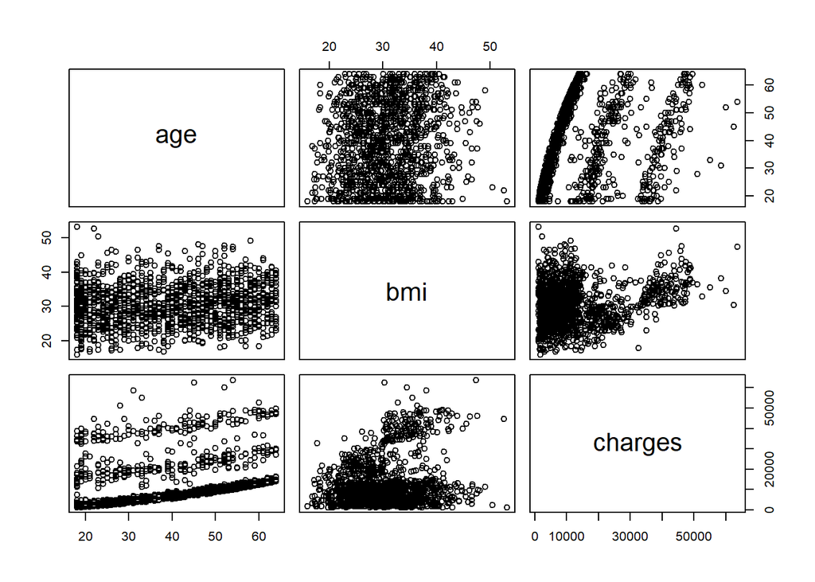

```r
plot(Insurance_Data.df[c(1, 3, 7)])
```

Since so many of the columns are factors they don’t really work as scatter plots. However, these three are the num columns and we can still get some info from them. The most interesting of these is Charges vs. Age, where there seems to be a sort of tiered correlation between the two.

```r
library(corrplot)
corr1 <- cor(Insurance_Data.df[, c(1,3,4,7)])
```

Correlation plots like this only accept numeric variables, so Age, BMI, Children, and Charges are the only usable columns.

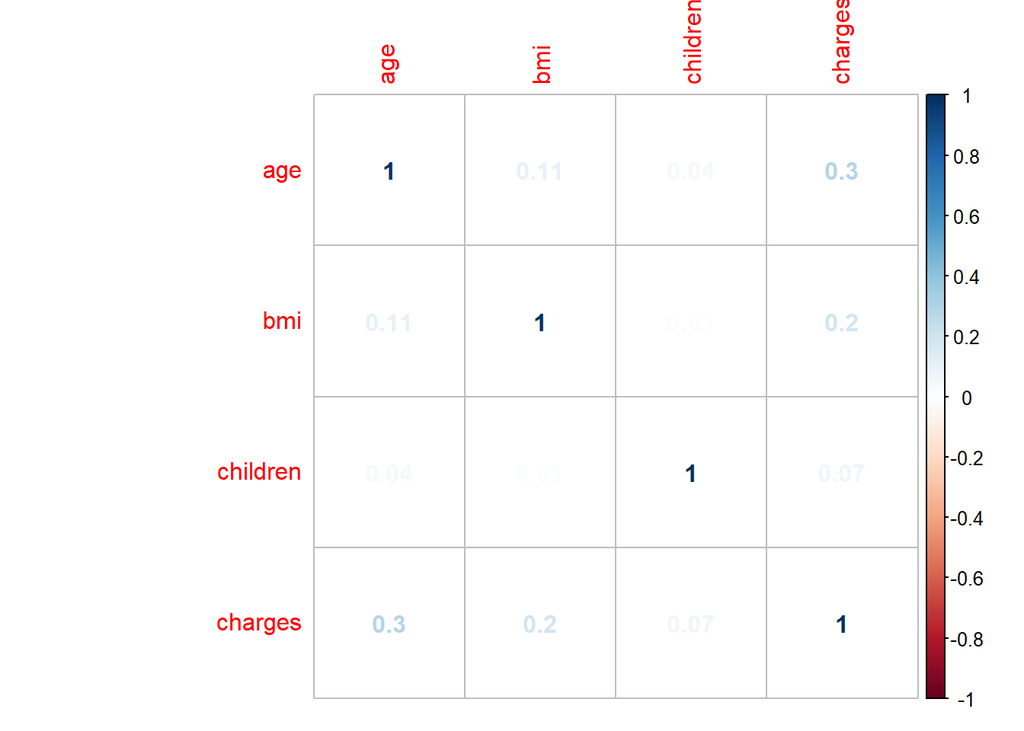

```r
corrplot(corr1, method="number")
```

Looking at this, everything but Age vs Charges has a virtually nonexistent correlation. This matches up well with our previous look at these two columns in the scatterplot above.

```r
library(rpivotTable)
rpivotTable(Insurance_Data.df)
```

[interactive table not shown]

After running a series of different combinations through the pivot table, several key points emerged. First, there is a strong positive correlation between Age and Charges (cost at 18 is 7k while cost at 60 is nearly 22k). Being a smoker also massively raises costs, with a nonsmoker paying an average of roughly 8500 while a smoker pays over 32000. It would seem that this would be because older people tend to be smokers, but studying the data reveal that smoking is much more prevalent among younger age brackets. There is a slight difference between the sexes, with men paying on average about 1500 more that women. Those in the SE tend to pay a little more than in the other regions, standing at an average of 14800 compared 12400 in the NW and SW.

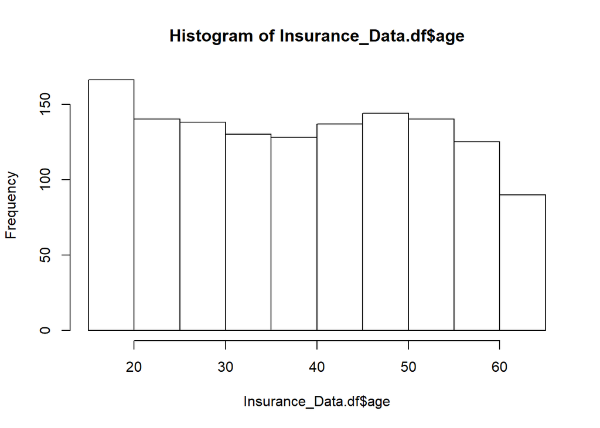

```r
hist(Insurance_Data.df$age)
```

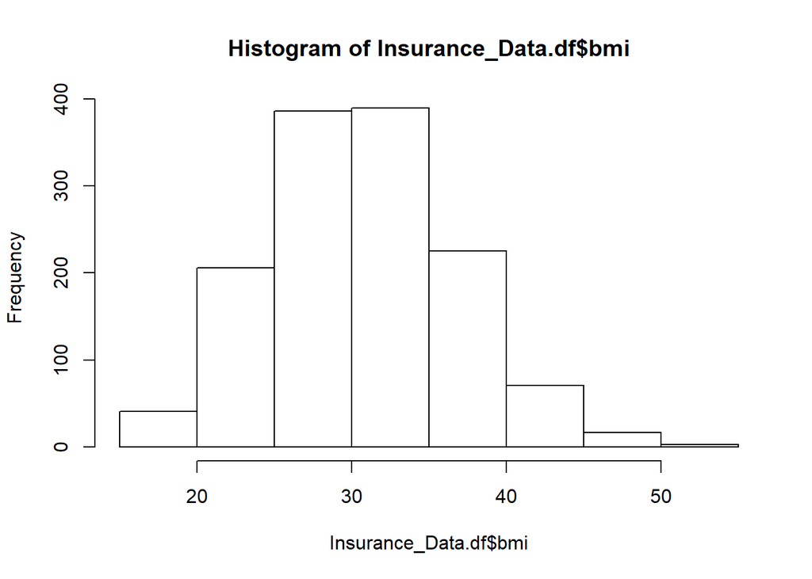

```r
hist(Insurance_Data.df$bmi)
```

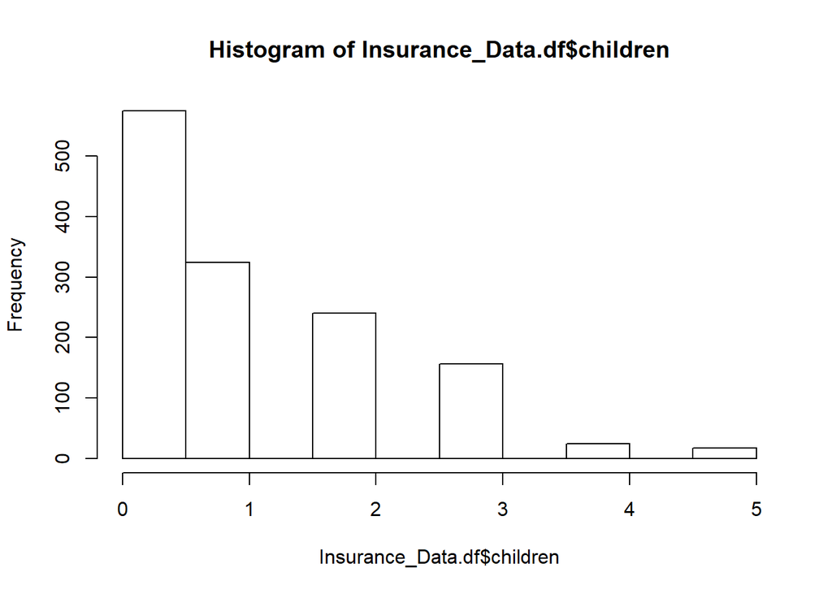

```r
hist(Insurance_Data.df$children)
```

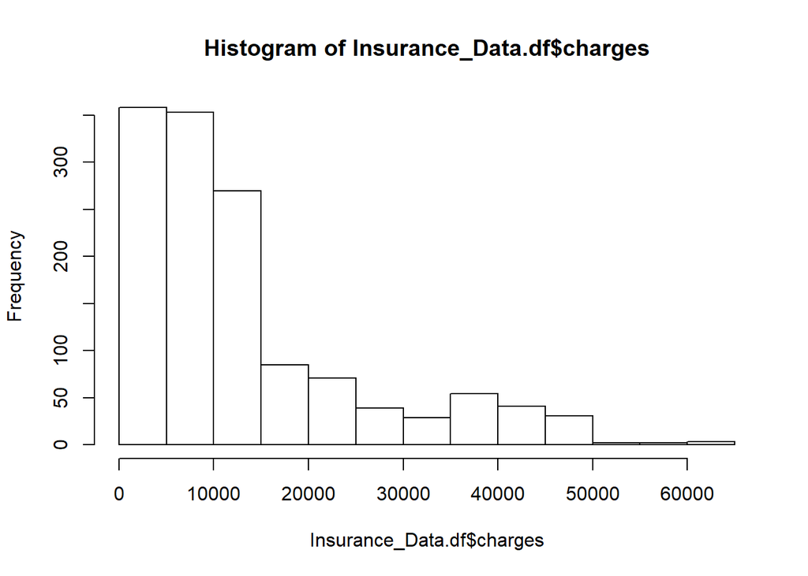

```r
hist(Insurance_Data.df$charges)
```

Again only numeric values are allowed for histograms and boxplots.

BMI is quite heavily centered around 25-35, which covers the somewhat overweight to mildly obese.

Most people pay less than 15k, with a few big spenders in the 40-60k range.

Most people have at least one child, however more than 3 is exceptionally uncommon.

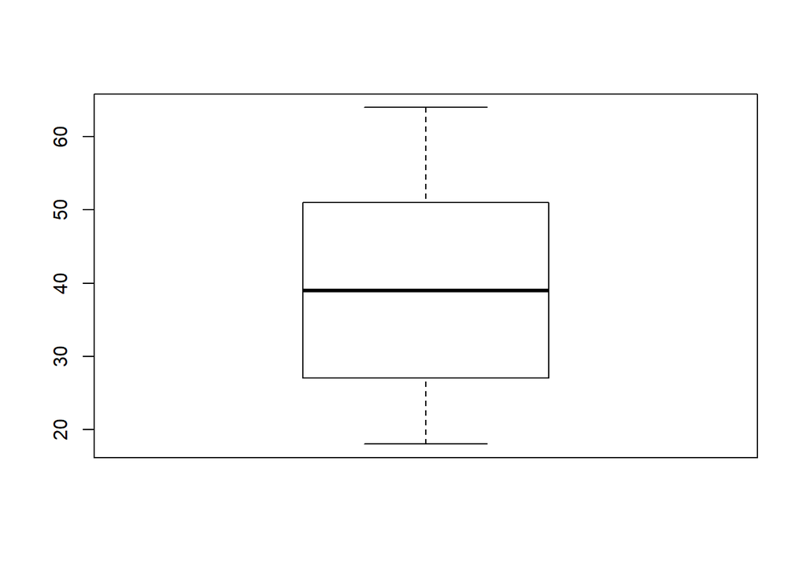

```r
boxplot(Insurance_Data.df$age)
```

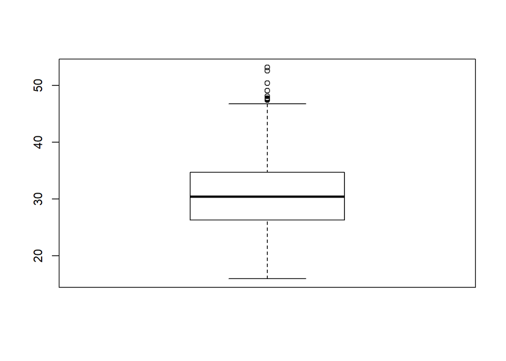

```r
boxplot(Insurance_Data.df$bmi)
```

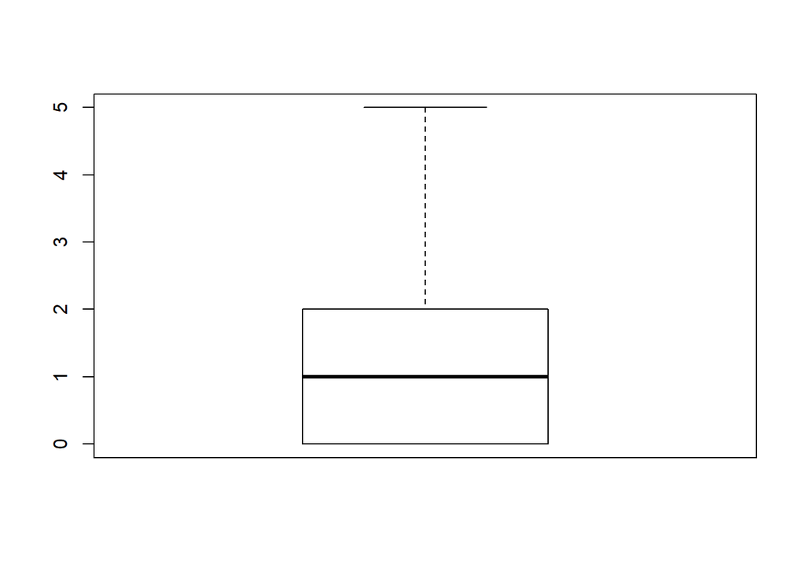

```r
boxplot(Insurance_Data.df$children)
```

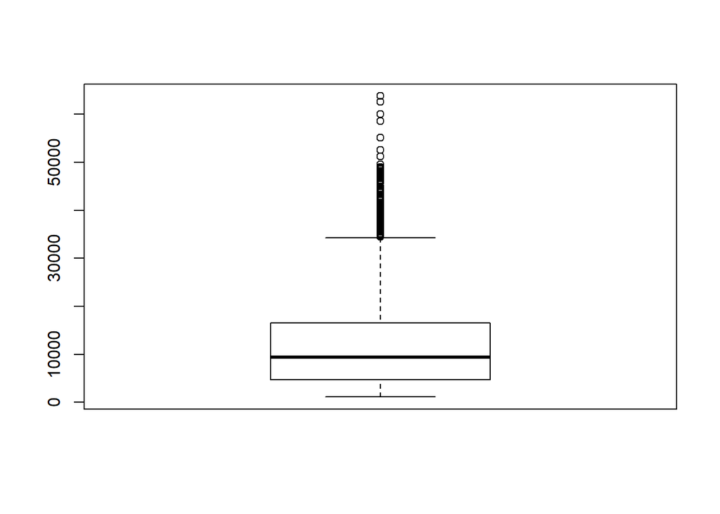

```r
boxplot(Insurance_Data.df$charges)
```

Age seems to have an extremely even ditribution, while charges is much more imbalance with a low mean but a large number of higher outliers.

```r
set.seed(123)
Insurance_Data.index <- Insurance_Data.df[order(runif(1339)), ]
train <- Insurance_Data.index[1:1071, ]
valid <- Insurance_Data.index[1072:1339, ]

dim(valid)
```

```
## [1] 268   7
```

```r
dim(train)
```

```
## [1] 1071    7
```

In this last section, we split the data into 80% and 20% sections. The 80% is used to train the model, while the 20% is set aside to score and validate it afterwards.